# Analyses for The Psychological Effects of Strength Exercises in People who are Overweight or Obese: A Systematic Review

Gill ten Hoor & Gjalt-Jorn Ygram Peters

2017-04-22 at 17:47:11

# Data loading and preparation

# Analyses

## Initial meta-analyses

These are the full results of the between-study meta-analyses. Note that the meta-analyses are not actually reported as such; as we explain, we use the quantitative integration of study results as reporting aid to visualise and explain the associations, but the quantitative outcomes are not discussed as such (see the next section).

```
## $r_0.3
## dat.rma[[paste0("r_", currentCorrelation)]]$category_variable: 1_disorders
##
## Random-Effects Model (k = 2; tau^2 estimator: REML)
##
## tau^2 (estimated amount of total heterogeneity): 0 (SE = 0.2410)
## tau (square root of estimated tau^2 value):      0
## I^2 (total heterogeneity / total variability):   0.00%
## H^2 (total variability / sampling variability):  1.00
##
## Test for Heterogeneity:
## Q(df = 1) = 0.5252, p-val = 0.4686
##
## Model Results:
##
## estimate       se     zval     pval    ci.lb    ci.ub
##  -0.7152   0.2872  -2.4900   0.0128  -1.2781  -0.1522        *
##
## ---
## Signif. codes:  0 '***' 0.001 '**' 0.01 '*' 0.05 '.' 0.1 ' ' 1
##
## --------------------------------------------------------
## dat.rma[[paste0("r_", currentCorrelation)]]$category_variable: 1_mood
##
## Random-Effects Model (k = 2; tau^2 estimator: REML)
##
## tau^2 (estimated amount of total heterogeneity): 0.0355 (SE = 0.0706)
## tau (square root of estimated tau^2 value):      0.1884
## I^2 (total heterogeneity / total variability):   71.12%
## H^2 (total variability / sampling variability):  3.46
##
## Test for Heterogeneity:
## Q(df = 1) = 3.4631, p-val = 0.0628
##
## Model Results:
##
## estimate       se     zval     pval    ci.lb    ci.ub
##  -0.0776   0.1576  -0.4921   0.6226  -0.3865   0.2313
##
## ---
```

[output cut: 1164 more lines]

```
## tau^2 (estimated amount of total heterogeneity): 0 (SE = 0.3636)
## tau (square root of estimated tau^2 value):      0
## I^2 (total heterogeneity / total variability):   0.00%
## H^2 (total variability / sampling variability):  1.00
##
## Test for Heterogeneity:
## Q(df = 1) = 0.0129, p-val = 0.9097
##
## Model Results:
##
## estimate       se     zval     pval    ci.lb    ci.ub
##   0.4496   0.2170   2.0719   0.0383   0.0243   0.8750        *
##
## ---
## Signif. codes:  0 '***' 0.001 '**' 0.01 '*' 0.05 '.' 0.1 ' ' 1
```

## Figures

### Plot 1

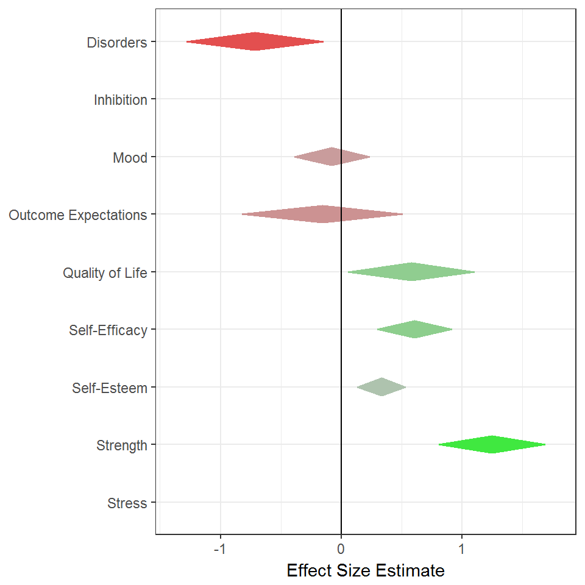

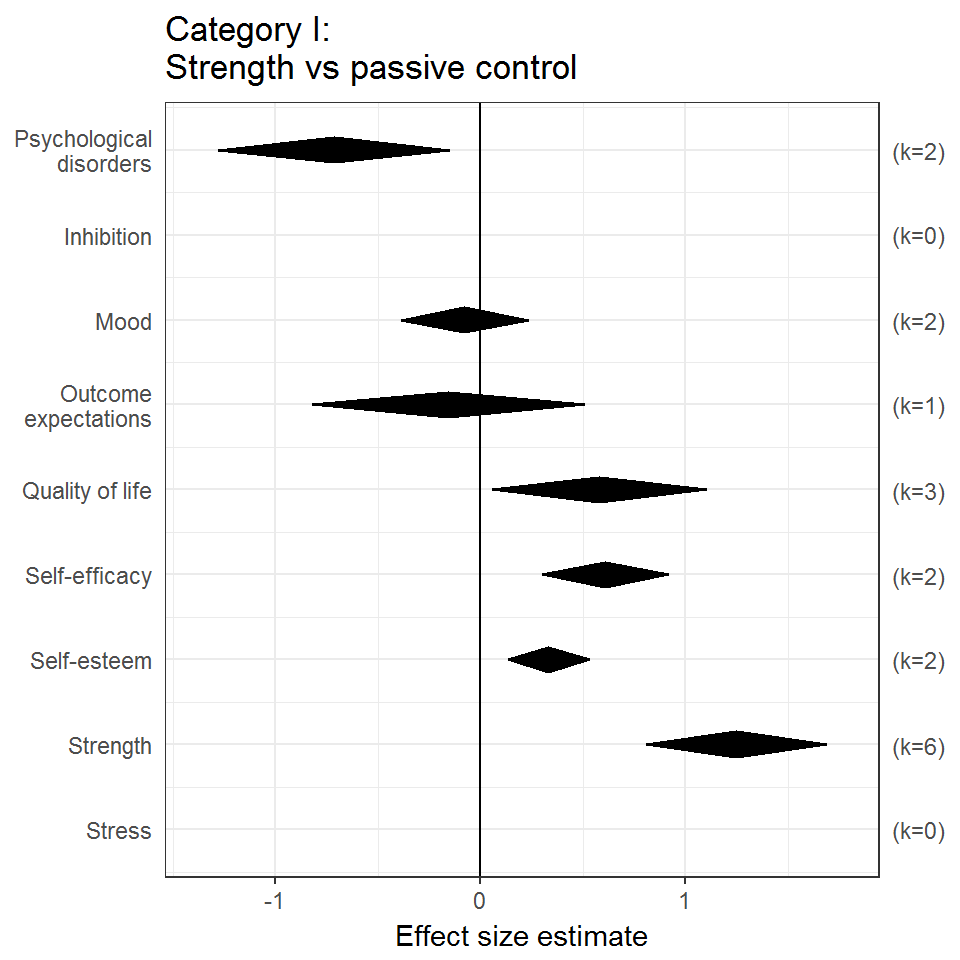

### Plot 2

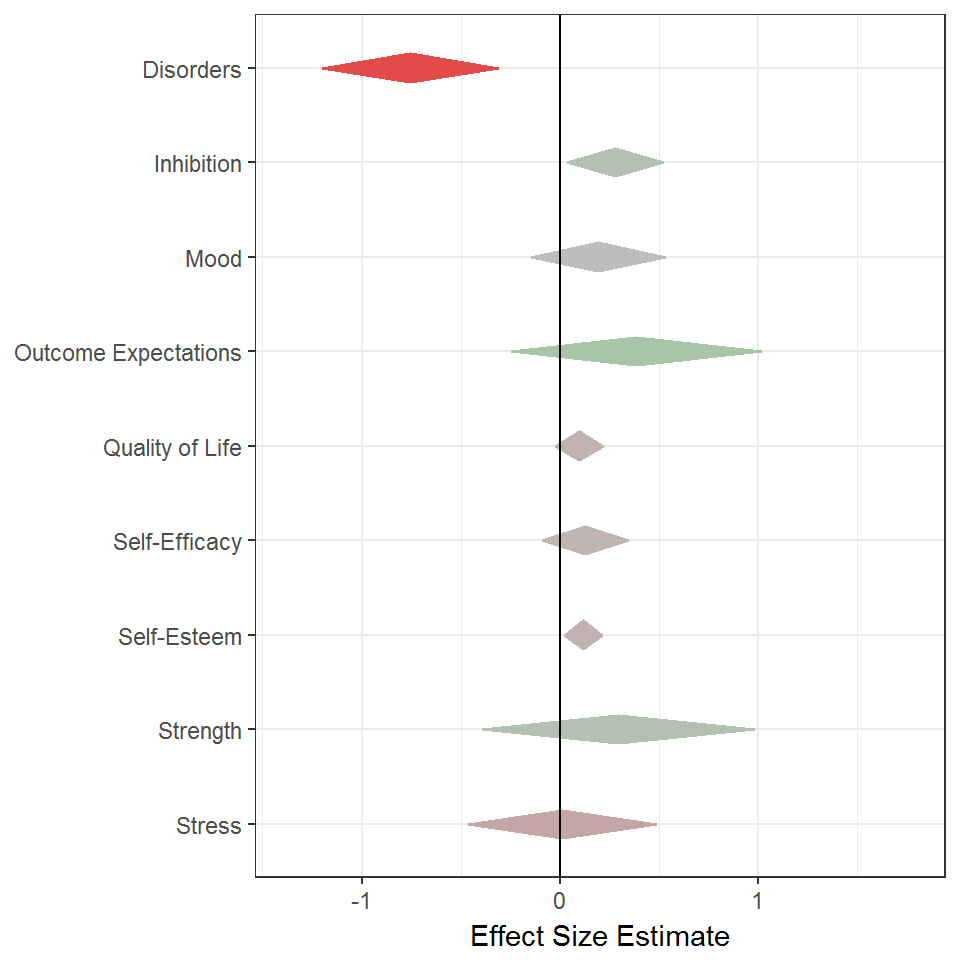

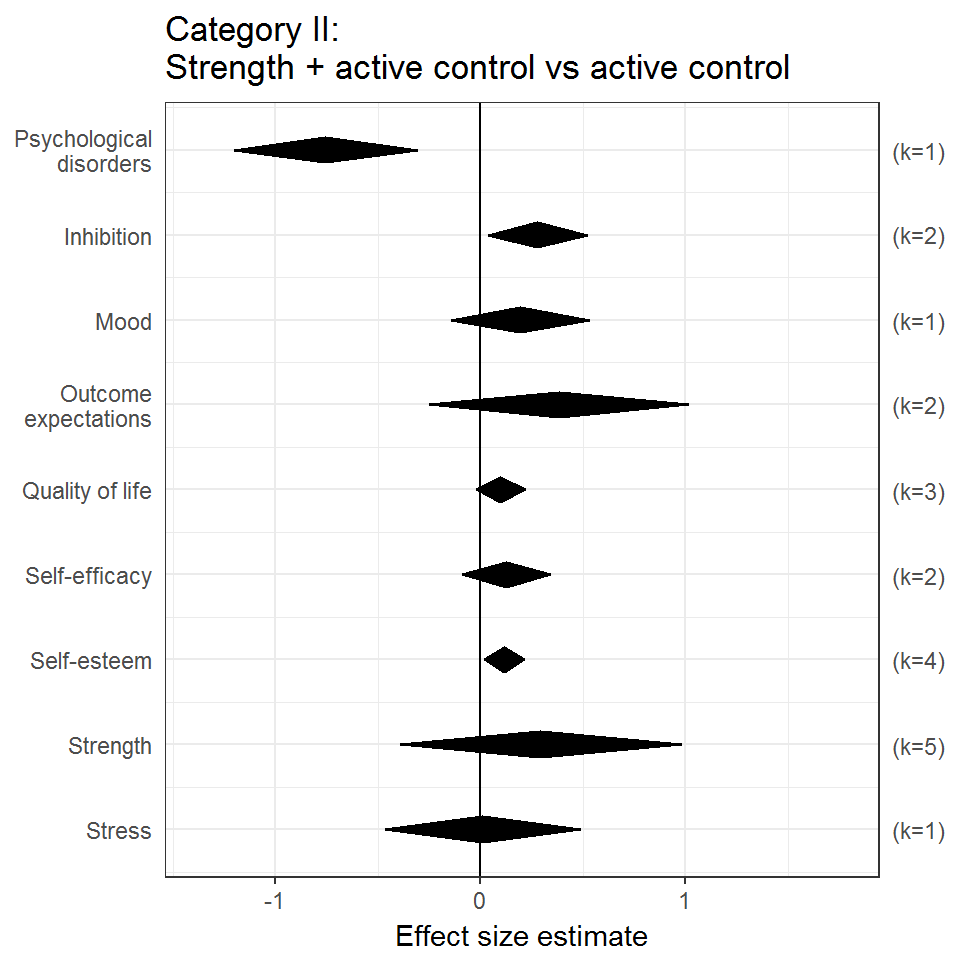

### Plot 3

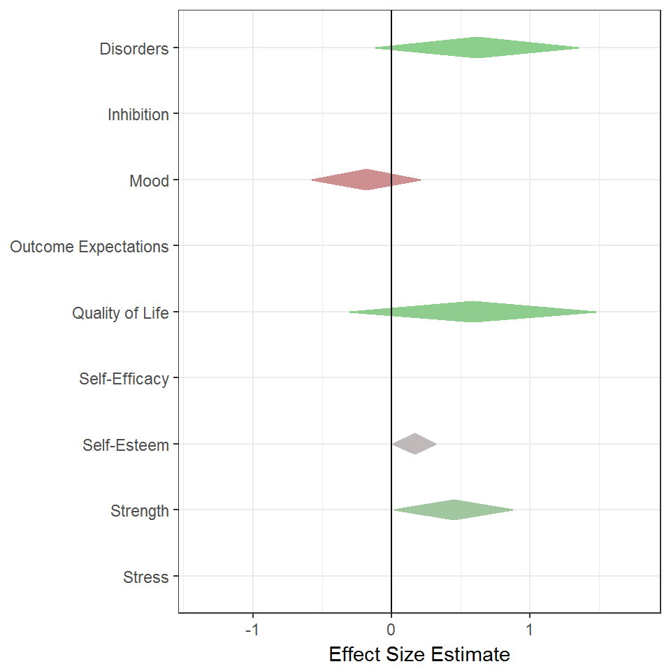

### Figure 2

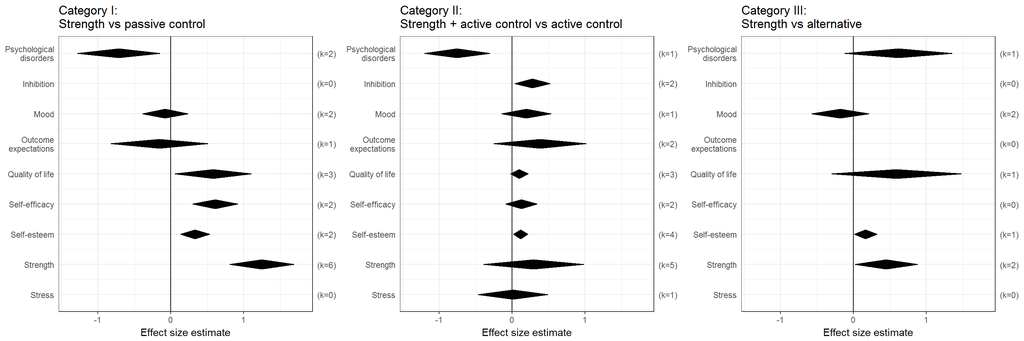

## Removing Levinger 2007

Because Levinger et al. (2007) only assessed acute effects (i.e. after only one training session), psychological effects can be expected to be different compared to those found in studies of effects of more long-term training, as commented by reviewer 2. Therefore, we repeat the analyses without Levinger2007.

Reviewer 2 also remarked that conducting meta-analyses with few studies, especially if heterogeneity was high, is problematic. We acknowledge these problems, and therefore, will not report the results of the meta-analyses except for emphasizing this heterogeneity. We will, however, still use the technique of quantitative integration of study results to help make sense of the data. In other words, we use it as a reporting tool in the systematic review rather than as a meta-analytical technique.

## Figures

### Plot 1

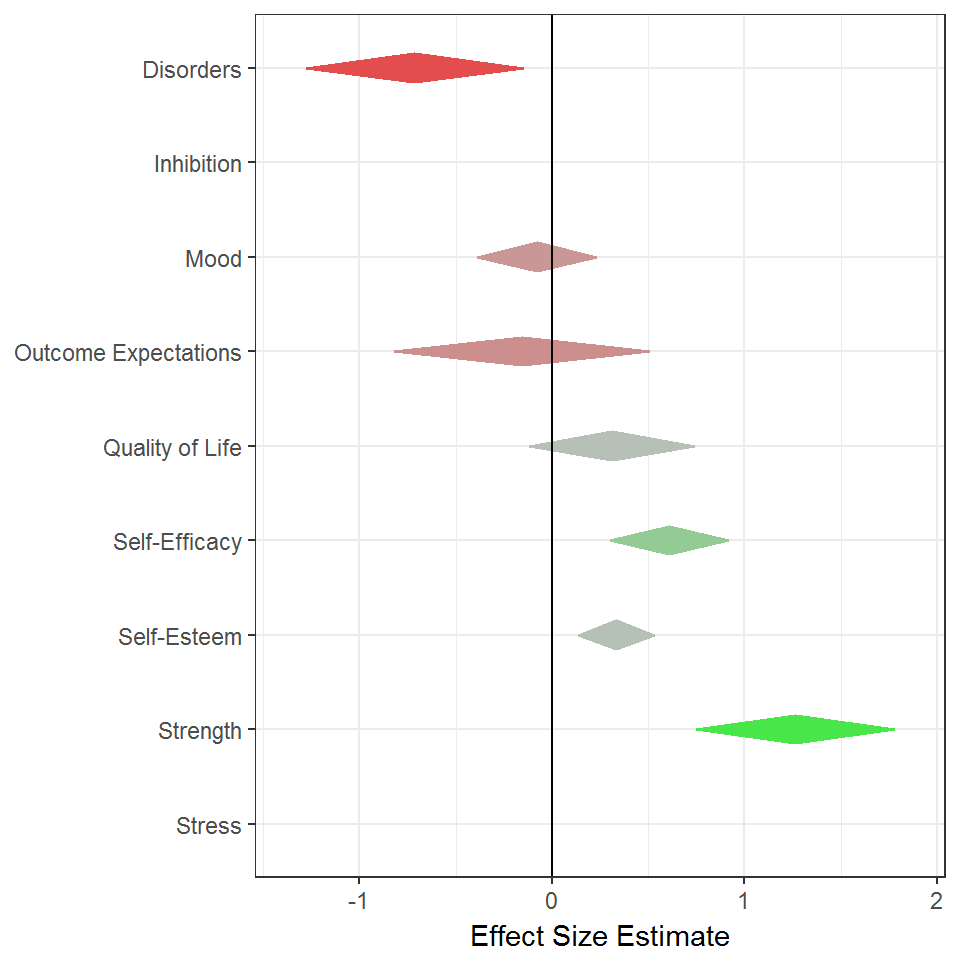

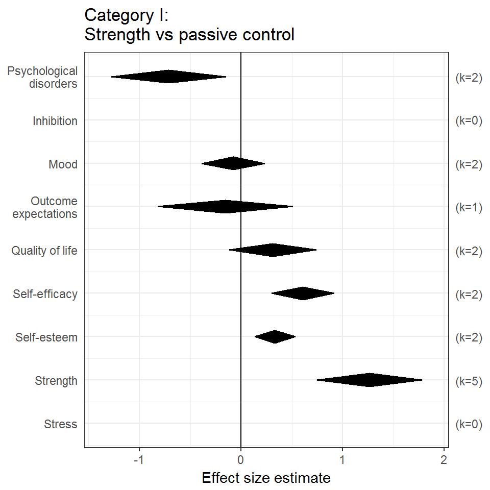

### Plot 2

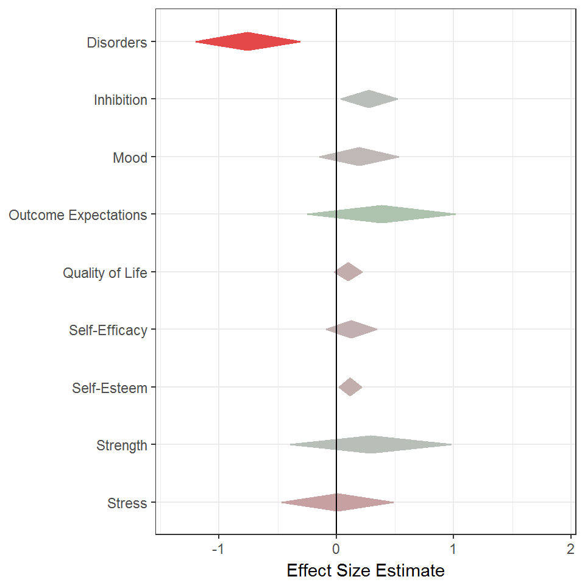

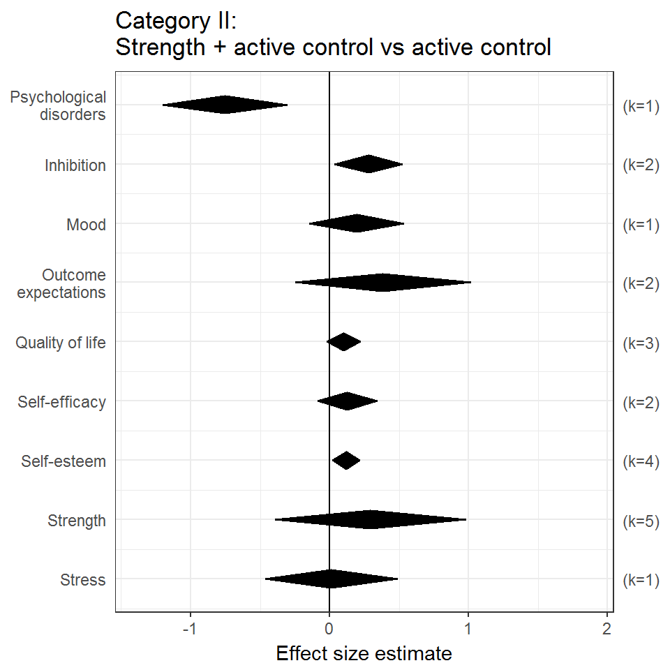

### Plot 3

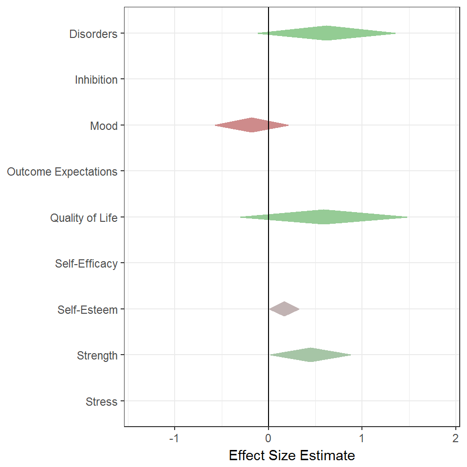

### Figure 2

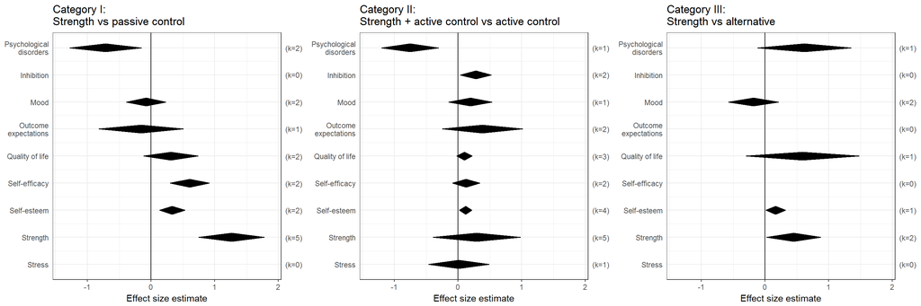

### Figure 2, split by age

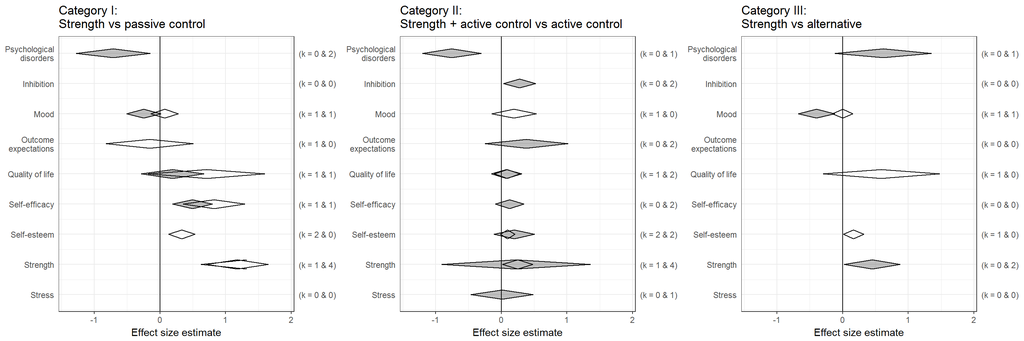